# Développement web dlm3

## Présentation du cours

# Programme

- Frameworks MVC : Laravel, Django, …
- HTML5 : vue d’ensemble
- Javascript : VueJS, Node.js, jQuery, AJAX, JSON, …
- Déploiement et configuration Serveur
- Webservices : REST vs SOAP
- Sécurité : Technologies, prévention des risques courants
- (Responsive) Web Design
- (Syndication : RSS, Atom)
- Vos souhaits ?

# Contenu, activités

- Cours théorique
- 2 Projets
  - 2 frameworks : Laravel & Django (ouvert à d’autres propositions)
  - Groupes de 3, [30h](https://www.he-arc.ch/reglementation) par personne et par projet
  - Présentation de 20min
- Workshops intervenants externes
  - Webdesign ([A. Keller](https://www.alinekeller.ch)) ?
  - Flask ([M. Amiguet](http://www.matthieuamiguet.ch/)) ?
  - Automatisation du déploiement ([R. Emourgeon](https://www.linkedin.com/in/raphaelemourgeon/)) ?
  - Vos présentations ? Vos propositions ?
- Support : [ghpages](https://he-arc.github.io/slides-devweb/) ([source](https://github.com/HE-Arc/slides-devweb/tree/master/src)), …ProfsAEtudiants\3255_Technologies_Interaction\dw

# Projets

- Faire pour apprendre
- Les rôles dans une équipe de développement web, workflow
- Ne pas réinventer la roue ou tout faire soi-même
- Critères d’évaluation d’un projet
- En profiter pour apprendre des choses qui vous intéressent
- Avant le 1er octobre :
  - Avoir un compte github avec une [clé SSH](https://github.com/settings/keys) (indispensable au déploiement)
  - Constitution des équipes de 3 personnes
  - Choix du projet
  - Forge : Créer projet sur github dans l’entité [HE-Arc](https://github.com/HE-Arc/)
  - [S’inscrire](https://github.com/HE-Arc/slides-devweb/wiki/Projets-2020-2021)
- Offre d’essai Pluralsight 1-6 mois sur [MS Imagine](https://my.visualstudio.com/Benefits), [infos](https://docs.microsoft.com/fr-fr/visualstudio/subscriptions/vs-pluralsight)

# Choix des projets

- Contrainte : appli basée sur des données
- Choix
  - Besoin réel
  - Données existantes : [dbpedia](http://wiki.dbpedia.org/), [opendata](https://opendata.swiss/fr/), …
  - S’inspirer de l’existant :
    - [Product Hunt](https://www.producthunt.com/topics/web-app), [makeuseof](http://www.makeuseof.com/tag/best-websites-internet/), …
    - [Volées précédentes](https://he-arc.github.io)
- Commencer tôt pour se libérer les dernières semaines de l’année

# Calendrier

| Semaine | Automne | Semaine | Printemps |
| --- | --- | --- | --- |
| 38 |  | 8 |  |
| 39 | Projet PHP | 9 |  |
| 40 |  | 10 |  |
| 41 |  | 11 |  |
| 43 |  | 12 |  |
| 44 |  | 13 |  |
| 45 |  | 15 |  |
| 46 |  | 16 | Présentations |
| 47 | S. thématique | 17 | Présentations |
| 48 |  | 18 | Présentations |
| 49 |  | 19 |  |
| 50 |  | 20 | Examens |
| 51 | Présentations | 21 | Début TB |
| 2 | Projet Python |  |  |
| 3 |  |  |  |
| 4 |  |  |  |
| 5 | T. Autonome |  |  |
| 6 | Examen |  |  |

# Suivi du calendrier (à jour sur le réseau interne)

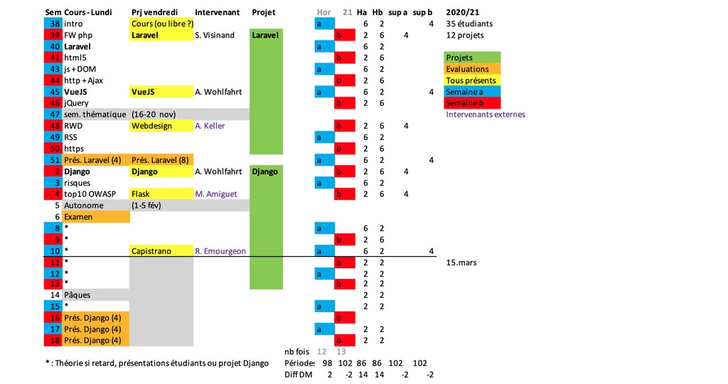

Suivi calendrier

# Jalons pour chacun des 2 projets

- Echéances
  - En début de semaine, pour chacun des projets :
    1. Formation équipe et choix thème
    2. Objectifs et maquettes
    3. Authentification et 1er déploiement
    5. Modèles avec relations (au moins 3, dont 1 n-n)
    7. Minimal Viable Product
    11. Rendu projet, Présentation
- Il n’est pas interdit d’en ajouter

# Conseils

- Le plus simple possible
- Pas trop de données
- Application crédible (vraies données, cas réalistes)
- Projet à blanc pour la prise en main du framework
- [Maquettes](https://brainhub.eu/blog/difference-between-wireframe-mockup-prototype/)
- [Organisez](http://drewfradette.ca/a-simpler-successful-git-branching-model/) l’utilisation du dépôt
- Le temps disponible à l’horaire ne suffira pas !
- Essayez de commit avec la même identité
- Signalez dans le commit msg si vous n’êtes pas l’auteur
- Le déploiement est long : commencez tôt !
- Il est moins risqué travailler plus au début du projet qu’à la fin !
- Discutez ! Echangez ! par exemple avec les vieux sur [gitter](https://gitter.im/HE-Arc)

# Évaluation des projets

- Note finale d’un projet :
  - User Experience : 50%
    - Design UI, Utilisabilité (Efficacité, efficience, satisfaction)
  - Code : 30%
    - Absence bugs, qualité code, lisibilité, respect conventions et bonnes pratiques
    - Déploiement, configuration
  - Gestion de projet : 20%
    - Fichiers versionnés, messages de commit, Issues, planification, travail en équipe
    - Documentation (wiki), Investissement, volume de travail
  - Bonus (ceux qui vont plus loin) : 0-20%
    - WebSockets ou autre API HTML5, webservices, …
    - Contribution, présentation, documentation, …
- Tous les membres d’un groupe n’ont pas forcément la même note

# Participation

- Aux projets des autres : Issues, PR
- Participez à la [Hacktoberfest](https://hacktoberfest.digitalocean.com/)
- Pariticipez au cours : contenu, présentation, pages (index, wiki, …)

# Présentation facultative

- Facultatif, ne peut qu’augmenter la moyenne
- DOIT être annoncé au semestre d’automne
- Un thème absent du cours
- 2 à 4 personnes
- Une présentation claire avec démo (printemps)
- Un exercice d’application
- Critiques et discussion
- Au plus tôt :
  - Constitution des équipes
  - Proposer 1 à 3 thèmes
  - [Proposer](https://docs.google.com/spreadsheet/viewform?formkey=dEVJRE1WVTVPelhFcE94TGF5N1c0cGc6MQ) le(s) thème(s) de présentation et l’équipe

# Examen oral SA

- Généralités pour la partie dev web de l’examen :
  - Vous n’avez droit à rien : on vous mettra à disposition 1 crayon et du papier pour préparer votre présentation,
  - L’examen porte sur toute la matière vue au en cours (yc workshops),
  - Les questions sont générales, il s’agit de présenter des concepts vus en cours (souvent 1 chapitre), et expliquer certains mécanismes sous-jacents,
  - Il n’agit pas de réciter le contenu des slides par coeur, mais de les présenter avec vos propres mots (compréhension), et vos propres exemples.
- Généralités pour la partie dev mobile de l’examen :
  - Vous pourriez avoir un résumé personnel manuscrit, d’une feuille A4 recto-verso,
  - L’examen porte sur toute la matière vue en cours,
  - Les questions peuvent être théoriques ou/et pratiques.

# Examen oral SA

- Déroulement :
  - Vous tirez un n° de question au hasard pour chaque cours
  - Vous disposez de 15 min pour préparer une présentation de 10 min pour chacun des 2 cours (pendant la présentation de l’étudiant précédent)
  - Idéalement vous faites une présentation d’environ 10 min et les 5 min restantes sont dédiées aux questions (pour chacun des cours)

# Mesures sanitaires COVID-19

- Rentrée : 100% présentiel
- Etudiants portent le masque
- Enseignants portent le masque à moins d’1.50m
- Désinfection des mains avant d’entrer en salle
- Quarantaine :
  - courte en cas de suspicion : le temps d’avoir le résultat des tests (2-5j)
    - considérée comme une absence, nécessité d’un certificat, faire le nécessaire pour rattrapper
  - longue (14 jours) si test positif
  - quarantaine courte ou des enseignants : le cours sera donné via Teams si possible

# Mon expérience en développement web

- [Questionnaire](https://docs.google.com/spreadsheet/viewform?formkey=dDg5Znh5akRBV1hPbC1qYlVRV3BONFE6MQ) obligatoire (votre username github vous y sera demandé)